# Diabetes data: heplots and candisc examples

Michael Friendly

2025-11-05

## Background

Reaven and Miller (1979) examined the relationship among blood chemistry measures of glucose tolerance and insulin in 145 nonobese adults. They used the PRIM9 system at the Stanford Linear Accelerator Center to visualize the data in 3D, and discovered a peculiar pattern that looked like a large blob with two wings in different directions.

After further analysis, the subjects were classified as sub-clinical (chemical) diabetics, overt diabetics and normals. This study was influential in defining the stages of development of Type 2 diabetes. Overt diabetes is the most advanced stage, characterized by elevated fasting blood glucose concentration and classical symptoms. Preceding overt diabetes is the latent or chemical diabetic stage, with no symptoms of diabetes but demonstrable abnormality of oral or intravenous glucose tolerance.

The `Diabetes` data set is contained in the `heplots` package. This vignette uses these data to illustrate various graphical methods for multivariate linear models. As we’ll see, the data is peculiar in several respects and a standard MANOVA is problematic because some assumptions are violated. We treat this as a learning opportunity, because it allows us to illustrate several diagnostic plots. Some of the content here serves as an additional example for a recent paper on visualizing tests for equality of variance in MANOVA (Friendly & Sigal, 2017).

### Setting up

Load the required packages and the data

```r
library(heplots)
library(candisc)
library(car)
```

```r
data(Diabetes, package="heplots")
str(Diabetes)
## 'data.frame':    145 obs. of  6 variables:
##  $ relwt  : num  0.81 0.95 0.94 1.04 1 0.76 0.91 1.1 0.99 0.78 ...
##  $ glufast: int  80 97 105 90 90 86 100 85 97 97 ...
##  $ glutest: int  356 289 319 356 323 381 350 301 379 296 ...
##  $ instest: int  124 117 143 199 240 157 221 186 142 131 ...
##  $ sspg   : int  55 76 105 108 143 165 119 105 98 94 ...
##  $ group  : Factor w/ 3 levels "Normal","Chemical_Diabetic",..: 1 1 1 1 1 1 1 1 1 1 ...
```

The variables are:

- `relwt`: relative weight, expressed as the ratio of actual weight to expected weight, given the person’s height
- `glufast`: fasting plasma glucose level
- `glutest`: test plasma glucose level, a measure of glucose intolerance,
- `instest`: plasma insulin during test, a measure of insulin response to oral glucose,
- `sspg`: steady state plasma glucose, a measure of insulin resistance
- `group`: diagnostic group

`relwt` is not used in this example, but that is not for any principled reason.

## Data ellipsoids and homogeneity of variance

We start by plotting covariance ellipses for three of the variables in the data set. `heplots::covEllipses()` is similar to `dataEllipse()` in the `car` package, but tuned to plots designed to assess homogeneity of covariance matrices in MANOVA designs. It produces a scatterplot matrix of these when the `variables` argument is of length > 2.

```r
covEllipses(Diabetes[,2:5], Diabetes$group,
     variables=1:3,
   fill=TRUE, fill.alpha = 0.2,
   pooled=FALSE,
     col=c("blue", "red", "darkgreen")
  )
```

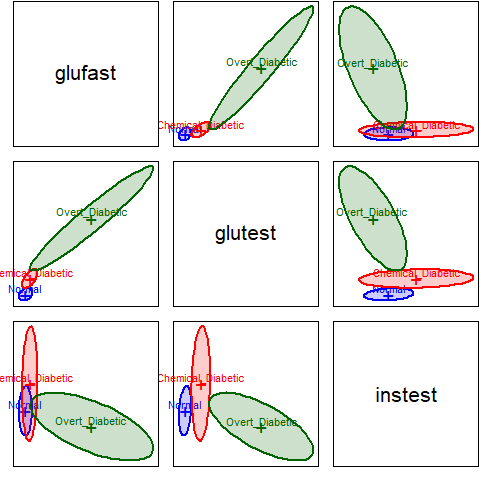

Plot matrix of data ellipses for diagnostic groups in three main variables of interest in the `Diabetes` dataset.

It is clear from this that there is a problem of heterogeneity of variance-covariance matrices here. The normal group shows the smallest variances and the overt diabetic group the largest.

As well, the plot suggests something more interesting about the difference between the overt and chemical diabetes groups. In the panel for `glufast` and `glutest`, there appears to be a direct progression from normal to chemical to overt. However, this is not true in the other panels, where the chemical diabetes group differs from the normals in one direction, while the overt group differs in a different direction and has a within-group correlation opposite in sign to the others.

This can be seen more easily in individual scatterplots, such as that below (using `car::scatterplot`).

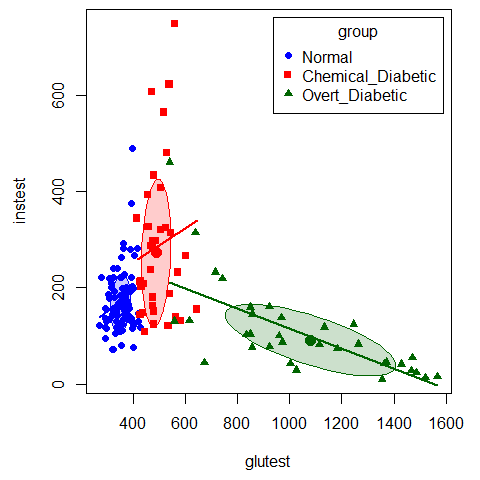

```r
scatterplot( instest ~ glutest | group, data=Diabetes,
   pch=c(16,15,17),
   col=c("blue", "red", "darkgreen"),
   smooth=FALSE,
   grid=FALSE,
   legend=list(coords="topright"),
   lwd=2,
   ellipse=list(levels=0.5))
```

This insight was part of the reason that Reaven and Miller concluded that chemical diabetes and overt diabetes reflected different disease regimes, rather than an increasing progression of severity.

As an aside, we note that the differences among the groups can be readily seen in 3D using `car::scatter3d()`. In an R console, the plot can be zoomed and rotated manually or under `rgl` controls.

```r
scatter3d(sspg ~ glutest + instest | group, data=Diabetes,
          surface=FALSE,    sphere.size=1.5, ellipsoid=TRUE,
          surface.col=c("blue", "red", "darkgreen"))
```

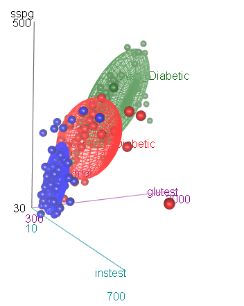

3D scatterplot of the diabetes data, with 50% data ellipsoids

### Box’s M test

Box’s M test confirms that there is substantial heterogeneity of covariance matrices. The `plot` method for the result gives a convenient and informative display of how the groups differ in the components ($log | S_i |$) that go into Box’s M test.

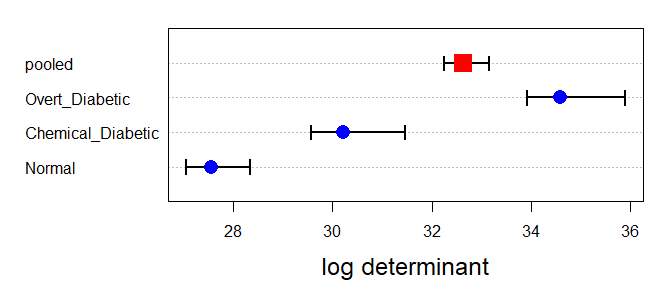

```r
diab.boxm <- boxM(Diabetes[,2:5], Diabetes$group)
diab.boxm
##
##  Box's M-test for Homogeneity of Covariance Matrices
##
## data:  Diabetes[, 2:5]
## Chi-Sq (approx.) = 383, df = 20, p-value <2e-16

op <- par(mar=c(4,6,1,1)+.5)
plot(diab.boxm, cex.lab=1.5)
```

The log determinants are ordered according to the sizes of the data ellipses we saw in the covariance ellipse plots.

## Fit the MLM

We ignore this problem for the sake of this example, and proceed to fit the MANOVA model for the mean differences among groups.

The MANOVA shows a highly significant effect of `group` on the collection of response variables.

```r
diab.mlm <- lm(cbind(glufast, glutest, instest, sspg) ~ group, data=Diabetes)
Anova(diab.mlm)
##
## Type II MANOVA Tests: Pillai test statistic
##       Df test stat approx F num Df den Df Pr(>F)
## group  2      1.18     50.1      8    280 <2e-16 ***
## ---
## Signif. codes:  0 '***' 0.001 '**' 0.01 '*' 0.05 '.' 0.1 ' ' 1
```

### Examine residuals in a QQ plot

Another assumption of MANOVA is that the residuals have a multivariate normal distribution. This can be assessed visually with a Chi-square QQ plot. This plots squared Mahalanobis distances ($D^2$) of the residuals vs. corresponding quantiles of the $\chi^2$ distribution with $p$ degrees of freedom. The `cqplot` function in the `heplots` package is designed to do this from a fitted MLM object. A confidence envelope makes it easy to see when the departure is large enough to cause concern.

It can be seen here that the points differ substantially from the red line of equality. There are far too many points with large $D^2$ values.

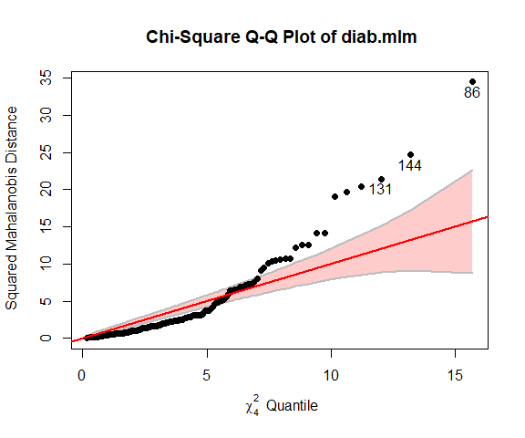

```r
cqplot(diab.mlm, id.n = 3)
```

## HE plots

An HE plot shows the $H$ ellipse for differences among means together with the $E$ ellipse for error. In the default scaling, such plots have the visual property that a given effect in the MLM is significant (by Roy’s maximum root test) *iff* the $H$ ellipse projects **anywhere** outside the $E$ ellipse.

By default, the first two response variables are plotted. The result shows that the means on both `glufast` and `glutest` are ordered `Normal < Chemical < Overt`.

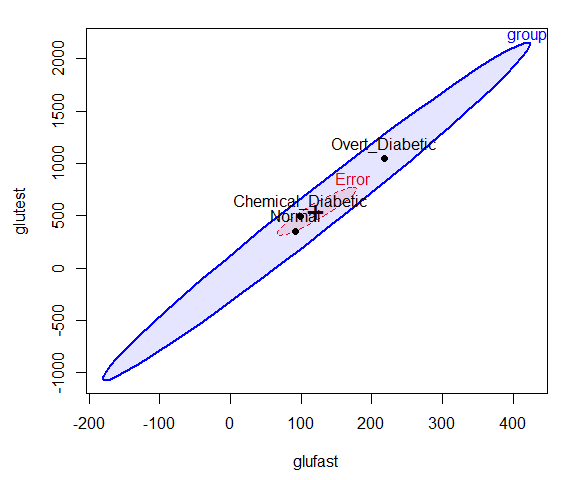

```r
heplot(diab.mlm, fill=TRUE, fill.alpha=0.1)
```

The `pairs` method for an MLM gives a scatterplot matrix of HE plots for all pairs of response variables. The pattern for `instest` seems to differ from the other variables.

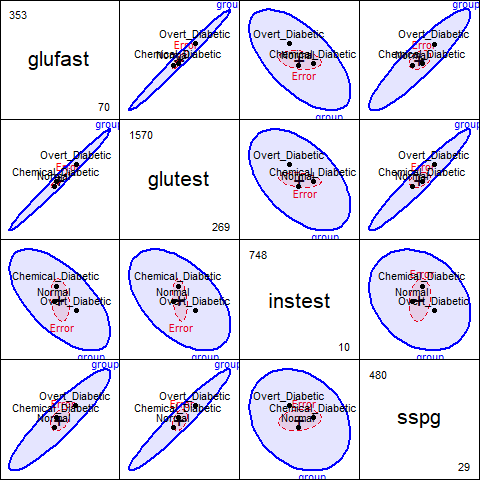

```r
pairs(diab.mlm, fill=TRUE, fill.alpha=0.1)
```

## Canonical discriminant analysis

Canonical discriminant analysis effectively projects the data into the space of linear combinations of the responses that accounts for the greatest proportion of the between-group variance relative to within-group variance.

In this case, with $g=3$ groups, this space is two-dimensional, so all differences can be seen in a 2D plot. From the output below, nearly 90% of between-group mean differences are accounted for by the first canonical dimension. Both canonical dimensions are significant, by a likelihood ratio stepdown test.

```r
diab.can <- candisc(diab.mlm)
diab.can
##
## Canonical Discriminant Analysis for group:
##
##   CanRsq Eigenvalue Difference Percent Cumulative
## 1  0.824      4.689       4.14    89.6       89.6
## 2  0.353      0.546       4.14    10.4      100.0
##
## Test of H0: The canonical correlations in the
## current row and all that follow are zero
##
##   LR test stat approx F numDF denDF Pr(> F)
## 1        0.114     68.3     8   278 < 2e-16 ***
## 2        0.647     25.5     3   140 3.3e-13 ***
## ---
## Signif. codes:  0 '***' 0.001 '**' 0.01 '*' 0.05 '.' 0.1 ' ' 1
```

### Canonical discriminant plot

The relationship of the response variables to the canonical dimensions is shown by vectors (similar to a biplot). Each vector is defined by the correlations (structure coefficients) it has with the canonical dimensions.[^1]

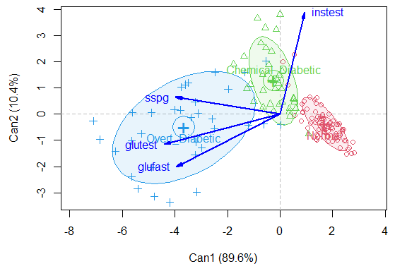

```r
plot(diab.can, ellipse=TRUE, var.lwd=2)
```

### Canonical HE plot

The `heplot` method for `candisc` objects gives an HE plot summary of the canonical discriminant analysis. The variable vectors are the same as in the canonical structure plot. The size of the $H$ ellipse relative to that of the $E$ ellipse is an indication of the magnitude of the multivariate effect for `group`.

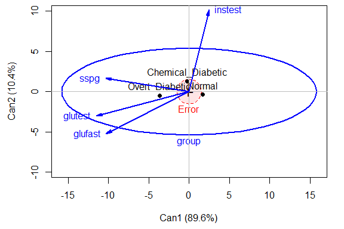

```
## Vector scale factor set to  12.06
```

```r
heplot(diab.can, fill=c(TRUE, FALSE), fill.alpha=0.1, var.lwd=2)
```

## Other analyses

There are other methods that could be used to analyze these data and display the results visually. We merely sketch some alternatives here.

### Linear and quadratic discriminant analysis

Linear discriminant analysis (LDA) is similar in spirit to MANOVA, but the emphasis is on classification rather than on testing differences among means. As well, LDA allows specification of the prior probabilities of group membership to make classification error rates comparable to what would be obtained in a population of interest. Quadratic discriminant analysis allows for differences in the covariance matrices among groups, and gives quadratic rather then linear classification boundaries.

LDA is in some sense equivalent to our canonical discriminant analysis. A simple function for this is `lda` in the `MASS` package. This gives the same class means and the same variance proportions as `candisc`. However, here, the prior probabilities are taken from the proportions of the groups in the data.

```r
library(MASS)
diab.lda <- lda(group ~ glufast + glutest + instest + sspg, data = Diabetes)
diab.lda
## Call:
## lda(group ~ glufast + glutest + instest + sspg, data = Diabetes)
##
## Prior probabilities of groups:
##            Normal Chemical_Diabetic    Overt_Diabetic
##            0.5241            0.2483            0.2276
##
## Group means:
##                   glufast glutest instest  sspg
## Normal              91.18   350.0   172.6 114.0
## Chemical_Diabetic   99.31   493.9   288.0 209.0
## Overt_Diabetic     217.67  1043.8   106.0 318.9
##
## Coefficients of linear discriminants:
##                LD1       LD2
## glufast  0.0326457 -0.038928
## glutest -0.0119958  0.006560
## instest  0.0003149  0.006202
## sspg    -0.0056269  0.003231
##
## Proportion of trace:
##    LD1    LD2
## 0.8958 0.1042
```

From the LDA perspective, one goal in visualizing the results is to see the boundaries of classification based on the `LD1` and `LD2` scores. The plot shown here was produced with `ggplot2`, following a method described in [this stackoverflow question](https://stackoverflow.com/questions/31893423/r-plotting-posterior-classification-probabilities-of-a-linear-discriminant-anal). What is missing here is any indication of how this relates to the response variables.

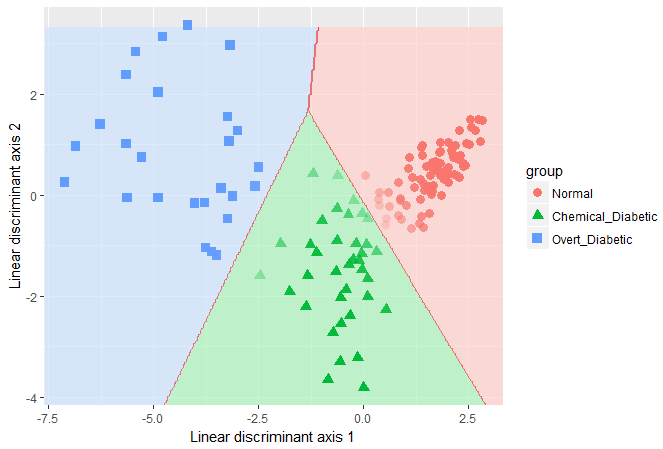

LDA classification for the diabetes data

Quadratic discriminant analysis can be carried out in a similar way, using the `qda` function. The results are not shown.

### Recursive partitioning

Recursive partitioning is a method that creates a decision tree designed to classify the members of a population. It recursively splits the data into sub-populations using dichotomous intervals of the predictors. One strength of the method is that it is nicely tied to *cross-validation*, where a sample is repeatedly split into training and test samples, and the model fit to each training sample is assessed on the test sample.

For the diabetes data, the result is very simple: A value of `glutest < 420` distinguishes normals from the two clinical groups. For the latter, `glufast < 117` classifies an individual as chemical diabetic rather than overt diabetic.

```r
library(rpart)
diab.part <- rpart(group ~ glufast + glutest + instest + sspg, data=Diabetes)
diab.part
## n= 145
##
## node), split, n, loss, yval, (yprob)
##       * denotes terminal node
##
## 1) root 145 69 Normal (0.52414 0.24828 0.22759)
##   2) glutest< 420.5 76  1 Normal (0.98684 0.01316 0.00000) *
##   3) glutest>=420.5 69 34 Chemical_Diabetic (0.01449 0.50725 0.47826)
##     6) glufast< 117 36  1 Chemical_Diabetic (0.02778 0.97222 0.00000) *
##     7) glufast>=117 33  0 Overt_Diabetic (0.00000 0.00000 1.00000) *
```

A nice plot of the partition tree is produced using the `rpart.plot` package. The numbers in the nodes give the proportions classified in each of the three groups.

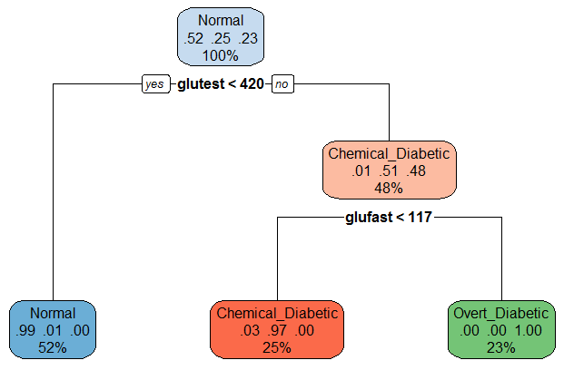

Recursive partition tree for diabetes data

```r
library(rpart.plot)
rpart.plot(diab.part, box.palette=list("Blues", "Reds",  "Greens"))
```

How well does that do? We can examine a table of predicted group membership vs. actual and calculate the error rate. Not too bad!

```r
(class.pred <- table(predicted=predict(diab.part, type="class"), actual=Diabetes$group))
##                    actual
## predicted           Normal Chemical_Diabetic Overt_Diabetic
##   Normal                75                 1              0
##   Chemical_Diabetic      1                35              0
##   Overt_Diabetic         0                 0             33

# error rate
1 - sum(diag(class.pred))/sum(class.pred)
## [1] 0.01379
```

## References

Friendly, M. & Sigal, M. (2017) Visualizing Tests of Equality of Covariance Matrices. Submitted for publication.

Reaven, G. M. & Miller, R. G. (1979). An Attempt to Define the Nature of Chemical Diabetes Using a Multidimensional Analysis *Diabetologia*, **16**, 17-24.

[^1]: The structure coefficients determine only the angle of the vector with respect to the coordinate axes. The vectors are all multiplied by a scale factor, chosen so the vectors nearly fill the plot frame.